# Gather

```python
import pandas as pd
df = pd.read_csv('twitter-archive-enhanced.csv')
df.head(50)
```

[output not shown]

```python
import requests
import os
import urllib

url = 'https://d17h27t6h515a5.cloudfront.net/topher/2017/August/599fd2ad_image-predictions/image-predictions.tsv'

response = requests.get(url)

filename = os.path.join('/home/workspace', 'image_predictions.tsv')
urllib.request.urlretrieve(url, filename)
```

```
('/home/workspace/image_predictions.tsv',
 <http.client.HTTPMessage at 0x7f80c36555f8>)
```

```python
images = pd.read_csv('image_predictions.tsv', sep='\t')

images.head(50)
```

[output not shown]

```python
import tweepy

consumer_key = 'hidden'
consumer_secret = 'hidden'
access_token = 'hidden'
access_secret = 'hidden'
auth = tweepy.OAuthHandler(consumer_key, consumer_secret)
auth.set_access_token(access_token, access_secret)

api = tweepy.API(auth)

user = api.get_user('dog_rates')
with open('tweet_json.txt', 'w') as file:
    file.write('tweet_id,favorite_count,retweet_count' + '\n')
    for tweetid in df['tweet_id']:
        try:
            file.write(str(tweetid) + ',' + str(api.get_status(tweetid).favorite_count) + ',' + str(api.get_status(tweetid).retweet_count) + '\n')
        except:
            pass
```

```python
df_json = pd.read_csv('tweet_json.txt')
```

```python
df_json.head()
```

|  | tweet_id | favorite_count | retweet_count |
| --- | --- | --- | --- |
| 0 | 892420643555336193 | 38950 | 8633 |
| 1 | 892177421306343426 | 33348 | 6341 |
| 2 | 891815181378084864 | 25122 | 4208 |
| 3 | 891689557279858688 | 42291 | 8756 |
| 4 | 891327558926688256 | 40455 | 9512 |

```python
df.info()
```

```
<class 'pandas.core.frame.DataFrame'>
RangeIndex: 2356 entries, 0 to 2355
Data columns (total 17 columns):
tweet_id                      2356 non-null int64
in_reply_to_status_id         78 non-null float64
in_reply_to_user_id           78 non-null float64
timestamp                     2356 non-null object
source                        2356 non-null object
text                          2356 non-null object
retweeted_status_id           181 non-null float64
retweeted_status_user_id      181 non-null float64
retweeted_status_timestamp    181 non-null object
expanded_urls                 2297 non-null object
rating_numerator              2356 non-null int64
rating_denominator            2356 non-null int64
name                          2356 non-null object
doggo                         2356 non-null object
floofer                       2356 non-null object
pupper                        2356 non-null object
puppo                         2356 non-null object
dtypes: float64(4), int64(3), object(10)
memory usage: 313.0+ KB
```

For the given data set, we have a total of 2356 rows and 17 columns.

```python
images.info()
```

```
<class 'pandas.core.frame.DataFrame'>
RangeIndex: 2075 entries, 0 to 2074
Data columns (total 12 columns):
tweet_id    2075 non-null int64
jpg_url     2075 non-null object
img_num     2075 non-null int64
p1          2075 non-null object
p1_conf     2075 non-null float64
p1_dog      2075 non-null bool
p2          2075 non-null object
p2_conf     2075 non-null float64
p2_dog      2075 non-null bool
p3          2075 non-null object
p3_conf     2075 non-null float64
p3_dog      2075 non-null bool
dtypes: bool(3), float64(3), int64(2), object(4)
memory usage: 152.1+ KB
```

For the images data set we pulled using Python programming, we have 2075 rows with 12 columns.

```python
df_json.info()
```

```
<class 'pandas.core.frame.DataFrame'>
RangeIndex: 445 entries, 0 to 444
Data columns (total 3 columns):
tweet_id          445 non-null int64
favorite_count    445 non-null int64
retweet_count     445 non-null int64
dtypes: int64(3)
memory usage: 10.5 KB
```

Finally, for the JSON data from tweepy, we have 445 rows with 3 columns.

# Assess

## Quality

- Lots of NaN values in various columns
- rating numerator and denominator are ints, should be floats (some observations have decimals)
- "Timestamp" column is wrong datatype, should be datetime, is string
- "source" column has unnecessary HTML; anchor tag with the source inside: Twitter mobile, vine, Twitter Web or Tweetdeck
- "retweeted_status_timestamp" column is wrong datatype, should be datetime, is string
- "tweet_id" should be a string, not an int
- "in_reply_to_user_id" is wrong datatype, should be string, not float
- "in_reply_to_status_id" is wrong datatype, should be string, not float
- "img_num" column in images dataframe is meaningless, all rows have one image regardless of the number in img_num
- Retweets need to be removed so we don't have duplicated data

## Tidiness

- "doggo, floofer, pupper and puppo" columns are redundant. Could be reworked into one column "dog_type"
- Image predictions dataframe column names are not descriptive
- 3 separate dataframes that could be inner joined

# Clean

```python
# Not much we can do about the NaN values for retweets and replies and such, as this means the tweet
# was not a reply or a retweet.

# Let's make copies of the unclean datasets for cleaning.

df_clean = df.copy()
images_clean = images.copy()
df_json_clean = df_json.copy()
```

## Define

- Retweets need to be removed so we don't have duplicated data

## Code

```python
# remove retweets from dataframes

df_clean = df_clean[pd.isnull(df_clean.retweeted_status_id)]
df_clean = df_clean[pd.isnull(df_clean.retweeted_status_timestamp)]
df_clean = df_clean[pd.isnull(df_clean.retweeted_status_user_id)]
```

## Test

```python
df_clean.info()
```

```
<class 'pandas.core.frame.DataFrame'>
Int64Index: 2175 entries, 0 to 2355
Data columns (total 17 columns):
tweet_id                      2175 non-null int64
in_reply_to_status_id         78 non-null float64
in_reply_to_user_id           78 non-null float64
timestamp                     2175 non-null object
source                        2175 non-null object
text                          2175 non-null object
retweeted_status_id           0 non-null float64
retweeted_status_user_id      0 non-null float64
retweeted_status_timestamp    0 non-null object
expanded_urls                 2117 non-null object
rating_numerator              2175 non-null int64
rating_denominator            2175 non-null int64
name                          2175 non-null object
doggo                         2175 non-null object
floofer                       2175 non-null object
pupper                        2175 non-null object
puppo                         2175 non-null object
dtypes: float64(4), int64(3), object(10)
memory usage: 305.9+ KB
```

## Define

- "doggo, floofer, pupper and puppo" columns are redundant. Could be reworked into one column "dog_type"

## Code

```python
# create new column for dog keywords
df_clean['dog_keyword'] = df_clean['doggo'].replace('None', '') + df_clean['puppo'].replace('None','') + df_clean['pupper'].replace('None', '') + df_clean['floofer'].replace('None','')
```

```python
#drop unnecessary columns
df_clean.drop(['doggo','floofer','pupper','puppo'], axis=1, inplace=True)
```

## Test

```python
df_clean['dog_keyword'].value_counts()
```

```
                1831
pupper           224
doggo             75
puppo             24
doggopupper       10
floofer            9
doggofloofer       1
doggopuppo         1
Name: dog_keyword, dtype: int64
```

## Define

- rating numerators are ints, should be floats (some observations have decimals)

## Code

```python
# change ratings to floats

import re

df_clean['rating_numerator'] = df_clean['text'].str.extract(r'(\d+(\.\d+)?)\/\d+').astype(float)
```

## Test

```python
df_clean.info()
```

```
<class 'pandas.core.frame.DataFrame'>
Int64Index: 2175 entries, 0 to 2355
Data columns (total 14 columns):
tweet_id                      2175 non-null int64
in_reply_to_status_id         78 non-null float64
in_reply_to_user_id           78 non-null float64
timestamp                     2175 non-null object
source                        2175 non-null object
text                          2175 non-null object
retweeted_status_id           0 non-null float64
retweeted_status_user_id      0 non-null float64
retweeted_status_timestamp    0 non-null object
expanded_urls                 2117 non-null object
rating_numerator              2175 non-null float64
rating_denominator            2175 non-null int64
name                          2175 non-null object
dog_keyword                   2175 non-null object
dtypes: float64(5), int64(2), object(7)
memory usage: 254.9+ KB
```

## Define

- "Timestamp" column is wrong datatype, should be datetime, is string

## Code

```python
# Import datetime module to fix data types for timestamps
from datetime import datetime

df_clean['timestamp'] = pd.to_datetime(df_clean['timestamp'])
```

## Test

```python
type(df_clean['timestamp'][0])
```

```
pandas._libs.tslib.Timestamp
```

## Define

- "retweeted_status_timestamp" column is wrong datatype, should be datetime, is string

## Code

```python
# Fix wrong datatypes for retweeted status timestamp column
df_clean['retweeted_status_timestamp'] = pd.to_datetime(df_clean['retweeted_status_timestamp'])
```

## Test

```python
df_clean.info()
```

```
<class 'pandas.core.frame.DataFrame'>
Int64Index: 2175 entries, 0 to 2355
Data columns (total 14 columns):
tweet_id                      2175 non-null int64
in_reply_to_status_id         78 non-null float64
in_reply_to_user_id           78 non-null float64
timestamp                     2175 non-null datetime64[ns]
source                        2175 non-null object
text                          2175 non-null object
retweeted_status_id           0 non-null float64
retweeted_status_user_id      0 non-null float64
retweeted_status_timestamp    0 non-null datetime64[ns]
expanded_urls                 2117 non-null object
rating_numerator              2175 non-null float64
rating_denominator            2175 non-null int64
name                          2175 non-null object
dog_keyword                   2175 non-null object
dtypes: datetime64[ns](2), float64(5), int64(2), object(5)
memory usage: 334.9+ KB
```

## Define

- "source" column has unnecessary HTML; anchor tag with the source inside: Twitter mobile, vine, Twitter Web or Tweetdeck

## Code

```python
# use regular expression to scrape away the unwanted html tag for the source column

regex_pat = re.compile(r'<[^>]*>')
df_clean['source'] = df_clean['source'].str.replace(regex_pat, '')
```

## Test

```python
df_clean['source'].value_counts()
```

```
Twitter for iPhone     2042
Vine - Make a Scene      91
Twitter Web Client       31
TweetDeck                11
Name: source, dtype: int64
```

## Define

- "tweet_id" should be a string, not an int

## Code

```python
# convert tweet id to string

df_clean['tweet_id'] = df_clean['tweet_id'].astype(str)
images_clean['tweet_id'] = images_clean['tweet_id'].astype(str)
df_json_clean['tweet_id'] = df_json_clean['tweet_id'].astype(str)
```

## Test

```python
type(df_clean['tweet_id'][0])
```

```
str
```

```python
type(images_clean['tweet_id'][0])
```

```
str
```

```python
type(df_json_clean['tweet_id'][0])
```

```
str
```

## Define

- "in_reply_to_user_id" is wrong datatype, should be string, not float

## Code

```python
# convert reply to user id to string

df_clean['in_reply_to_user_id'] = df_clean['in_reply_to_user_id'].astype(str)
```

## Test

```python
df_clean.info()
```

```
<class 'pandas.core.frame.DataFrame'>
Int64Index: 2175 entries, 0 to 2355
Data columns (total 14 columns):
tweet_id                      2175 non-null object
in_reply_to_status_id         78 non-null float64
in_reply_to_user_id           2175 non-null object
timestamp                     2175 non-null datetime64[ns]
source                        2175 non-null object
text                          2175 non-null object
retweeted_status_id           0 non-null float64
retweeted_status_user_id      0 non-null float64
retweeted_status_timestamp    0 non-null datetime64[ns]
expanded_urls                 2117 non-null object
rating_numerator              2175 non-null float64
rating_denominator            2175 non-null int64
name                          2175 non-null object
dog_keyword                   2175 non-null object
dtypes: datetime64[ns](2), float64(4), int64(1), object(7)
memory usage: 334.9+ KB
```

## Define

- "in_reply_to_status_id" is wrong datatype, should be string, not float

## Code

```python
#convert reply to status id to string

df_clean['in_reply_to_status_id'] = df_clean['in_reply_to_status_id'].astype(str)
```

## Test

```python
df_clean.info()
```

```
<class 'pandas.core.frame.DataFrame'>
Int64Index: 2175 entries, 0 to 2355
Data columns (total 14 columns):
tweet_id                      2175 non-null object
in_reply_to_status_id         2175 non-null object
in_reply_to_user_id           2175 non-null object
timestamp                     2175 non-null datetime64[ns]
source                        2175 non-null object
text                          2175 non-null object
retweeted_status_id           0 non-null float64
retweeted_status_user_id      0 non-null float64
retweeted_status_timestamp    0 non-null datetime64[ns]
expanded_urls                 2117 non-null object
rating_numerator              2175 non-null float64
rating_denominator            2175 non-null int64
name                          2175 non-null object
dog_keyword                   2175 non-null object
dtypes: datetime64[ns](2), float64(3), int64(1), object(8)
memory usage: 334.9+ KB
```

## Define

- img_num column in the images dataframe is useless

## Code

```python
# remove useless img_num column

images_clean.drop('img_num', axis = 1, inplace = True)
```

## Test

```python
images_clean.head()
```

|  | tweet_id | jpg_url | p1 | p1_conf | p1_dog | p2 | p2_conf | p2_dog | p3 | p3_conf | p3_dog |
| --- | --- | --- | --- | --- | --- | --- | --- | --- | --- | --- | --- |
| 0 | 666020888022790149 | https://pbs.twimg.com/media/CT4udn0WwAA0aMy.jpg | Welsh_springer_spaniel | 0.465074 | True | collie | 0.156665 | True | Shetland_sheepdog | 0.061428 | True |
| 1 | 666029285002620928 | https://pbs.twimg.com/media/CT42GRgUYAA5iDo.jpg | redbone | 0.506826 | True | miniature_pinscher | 0.074192 | True | Rhodesian_ridgeback | 0.072010 | True |
| 2 | 666033412701032449 | https://pbs.twimg.com/media/CT4521TWwAEvMyu.jpg | German_shepherd | 0.596461 | True | malinois | 0.138584 | True | bloodhound | 0.116197 | True |
| 3 | 666044226329800704 | https://pbs.twimg.com/media/CT5Dr8HUEAA-lEu.jpg | Rhodesian_ridgeback | 0.408143 | True | redbone | 0.360687 | True | miniature_pinscher | 0.222752 | True |
| 4 | 666049248165822465 | https://pbs.twimg.com/media/CT5IQmsXIAAKY4A.jpg | miniature_pinscher | 0.560311 | True | Rottweiler | 0.243682 | True | Doberman | 0.154629 | True |

## Define

- images column names are not descriptive

## Code

```python
# rename columns in images_clean to be more descriptive

images_clean.rename(columns={'p1':'prediction_1', 'p1_conf':'prediction_1_confidence', 'p1_dog':'prediction_1_dog', 'p2':'prediction_2', 'p2_conf':'prediction_2_confidence', 'p2_dog':'prediction_2_dog', 'p3':'prediction_3', 'p3_conf':'prediction_3_confidence', 'p3_dog':'prediction_3_dog'}, inplace=True)
```

## Test

```python
images_clean.head()
```

|  | tweet_id | jpg_url | prediction_1 | prediction_1_confidence | prediction_1_dog | prediction_2 | prediction_2_confidence | prediction_2_dog | prediction_3 | prediction_3_confidence | prediction_3_dog |
| --- | --- | --- | --- | --- | --- | --- | --- | --- | --- | --- | --- |
| 0 | 666020888022790149 | https://pbs.twimg.com/media/CT4udn0WwAA0aMy.jpg | Welsh_springer_spaniel | 0.465074 | True | collie | 0.156665 | True | Shetland_sheepdog | 0.061428 | True |
| 1 | 666029285002620928 | https://pbs.twimg.com/media/CT42GRgUYAA5iDo.jpg | redbone | 0.506826 | True | miniature_pinscher | 0.074192 | True | Rhodesian_ridgeback | 0.072010 | True |
| 2 | 666033412701032449 | https://pbs.twimg.com/media/CT4521TWwAEvMyu.jpg | German_shepherd | 0.596461 | True | malinois | 0.138584 | True | bloodhound | 0.116197 | True |
| 3 | 666044226329800704 | https://pbs.twimg.com/media/CT5Dr8HUEAA-lEu.jpg | Rhodesian_ridgeback | 0.408143 | True | redbone | 0.360687 | True | miniature_pinscher | 0.222752 | True |
| 4 | 666049248165822465 | https://pbs.twimg.com/media/CT5IQmsXIAAKY4A.jpg | miniature_pinscher | 0.560311 | True | Rottweiler | 0.243682 | True | Doberman | 0.154629 | True |

## Define

- Three separate dataframes that could be inner joined

## Code

```python
df_final = pd.merge(df_clean, images_clean, on='tweet_id', how='inner')
df_final = pd.merge(df_final, df_json_clean, on='tweet_id', how='inner')
```

## Test

```python
df_final
```

|  | tweet_id | in_reply_to_status_id | in_reply_to_user_id | timestamp | source | text | retweeted_status_id | retweeted_status_user_id | retweeted_status_timestamp | expanded_urls | ... | prediction_1_confidence | prediction_1_dog | prediction_2 | prediction_2_confidence | prediction_2_dog | prediction_3 | prediction_3_confidence | prediction_3_dog | favorite_count | retweet_count |
| --- | --- | --- | --- | --- | --- | --- | --- | --- | --- | --- | --- | --- | --- | --- | --- | --- | --- | --- | --- | --- | --- |
| 0 | 892420643555336193 | nan | nan | 2017-08-01 16:23:56 | Twitter for iPhone | This is Phineas. He's a mystical boy. Only eve... | NaN | NaN | NaT | https://twitter.com/dog_rates/status/892420643... | ... | 0.097049 | False | bagel | 0.085851 | False | banana | 0.076110 | False | 38950 | 8633 |
| 1 | 892177421306343426 | nan | nan | 2017-08-01 00:17:27 | Twitter for iPhone | This is Tilly. She's just checking pup on you.... | NaN | NaN | NaT | https://twitter.com/dog_rates/status/892177421... | ... | 0.323581 | True | Pekinese | 0.090647 | True | papillon | 0.068957 | True | 33348 | 6341 |
| 2 | 891815181378084864 | nan | nan | 2017-07-31 00:18:03 | Twitter for iPhone | This is Archie. He is a rare Norwegian Pouncin... | NaN | NaN | NaT | https://twitter.com/dog_rates/status/891815181... | ... | 0.716012 | True | malamute | 0.078253 | True | kelpie | 0.031379 | True | 25122 | 4208 |
| 3 | 891689557279858688 | nan | nan | 2017-07-30 15:58:51 | Twitter for iPhone | This is Darla. She commenced a snooze mid meal... | NaN | NaN | NaT | https://twitter.com/dog_rates/status/891689557... | ... | 0.170278 | False | Labrador_retriever | 0.168086 | True | spatula | 0.040836 | False | 42291 | 8756 |
| 4 | 891327558926688256 | nan | nan | 2017-07-29 16:00:24 | Twitter for iPhone | This is Franklin. He would like you to stop ca... | NaN | NaN | NaT | https://twitter.com/dog_rates/status/891327558... | ... | 0.555712 | True | English_springer | 0.225770 | True | German_short-haired_pointer | 0.175219 | True | 40455 | 9512 |
| 5 | 891087950875897856 | nan | nan | 2017-07-29 00:08:17 | Twitter for iPhone | Here we have a majestic great white breaching ... | NaN | NaN | NaT | https://twitter.com/dog_rates/status/891087950... | ... | 0.425595 | True | Irish_terrier | 0.116317 | True | Indian_elephant | 0.076902 | False | 20292 | 3149 |
| 6 | 890971913173991426 | nan | nan | 2017-07-28 16:27:12 | Twitter for iPhone | Meet Jax. He enjoys ice cream so much he gets ... | NaN | NaN | NaT | https://gofundme.com/ydvmve-surgery-for-jax,ht... | ... | 0.341703 | True | Border_collie | 0.199287 | True | ice_lolly | 0.193548 | False | 11900 | 2100 |
| 7 | 890729181411237888 | nan | nan | 2017-07-28 00:22:40 | Twitter for iPhone | When you watch your owner call another dog a g... | NaN | NaN | NaT | https://twitter.com/dog_rates/status/890729181... | ... | 0.566142 | True | Eskimo_dog | 0.178406 | True | Pembroke | 0.076507 | True | 65802 | 19141 |
| 8 | 890609185150312448 | nan | nan | 2017-07-27 16:25:51 | Twitter for iPhone | This is Zoey. She doesn't want to be one of th... | NaN | NaN | NaT | https://twitter.com/dog_rates/status/890609185... | ... | 0.487574 | True | Irish_setter | 0.193054 | True | Chesapeake_Bay_retriever | 0.118184 | True | 27870 | 4317 |
| 9 | 890240255349198849 | nan | nan | 2017-07-26 15:59:51 | Twitter for iPhone | This is Cassie. She is a college pup. Studying... | NaN | NaN | NaT | https://twitter.com/dog_rates/status/890240255... | ... | 0.511319 | True | Cardigan | 0.451038 | True | Chihuahua | 0.029248 | True | 32054 | 7514 |
| 10 | 890006608113172480 | nan | nan | 2017-07-26 00:31:25 | Twitter for iPhone | This is Koda. He is a South Australian decksha... | NaN | NaN | NaT | https://twitter.com/dog_rates/status/890006608... | ... | 0.957979 | True | Pomeranian | 0.013884 | True | chow | 0.008167 | True | 30762 | 7431 |
| 11 | 889880896479866881 | nan | nan | 2017-07-25 16:11:53 | Twitter for iPhone | This is Bruno. He is a service shark. Only get... | NaN | NaN | NaT | https://twitter.com/dog_rates/status/889880896... | ... | 0.377417 | True | Labrador_retriever | 0.151317 | True | muzzle | 0.082981 | False | 27883 | 5027 |
| 12 | 889665388333682689 | nan | nan | 2017-07-25 01:55:32 | Twitter for iPhone | Here's a puppo that seems to be on the fence a... | NaN | NaN | NaT | https://twitter.com/dog_rates/status/889665388... | ... | 0.966327 | True | Cardigan | 0.027356 | True | basenji | 0.004633 | True | 48265 | 10183 |
| 13 | 889638837579907072 | nan | nan | 2017-07-25 00:10:02 | Twitter for iPhone | This is Ted. He does his best. Sometimes that'... | NaN | NaN | NaT | https://twitter.com/dog_rates/status/889638837... | ... | 0.991650 | True | boxer | 0.002129 | True | Staffordshire_bullterrier | 0.001498 | True | 27271 | 4596 |
| 14 | 889531135344209921 | nan | nan | 2017-07-24 17:02:04 | Twitter for iPhone | This is Stuart. He's sporting his favorite fan... | NaN | NaN | NaT | https://twitter.com/dog_rates/status/889531135... | ... | 0.953442 | True | Labrador_retriever | 0.013834 | True | redbone | 0.007958 | True | 15140 | 2262 |
| 15 | 889278841981685760 | nan | nan | 2017-07-24 00:19:32 | Twitter for iPhone | This is Oliver. You're witnessing one of his m... | NaN | NaN | NaT | https://twitter.com/dog_rates/status/889278841... | ... | 0.626152 | True | borzoi | 0.194742 | True | Saluki | 0.027351 | True | 25396 | 5497 |
| 16 | 888917238123831296 | nan | nan | 2017-07-23 00:22:39 | Twitter for iPhone | This is Jim. He found a fren. Taught him how t... | NaN | NaN | NaT | https://twitter.com/dog_rates/status/888917238... | ... | 0.714719 | True | Tibetan_mastiff | 0.120184 | True | Labrador_retriever | 0.105506 | True | 29189 | 4561 |
| 17 | 888804989199671297 | nan | nan | 2017-07-22 16:56:37 | Twitter for iPhone | This is Zeke. He has a new stick. Very proud o... | NaN | NaN | NaT | https://twitter.com/dog_rates/status/888804989... | ... | 0.469760 | True | Labrador_retriever | 0.184172 | True | English_setter | 0.073482 | True | 25689 | 4396 |
| 18 | 888554962724278272 | nan | nan | 2017-07-22 00:23:06 | Twitter for iPhone | This is Ralphus. He's powering up. Attempting ... | NaN | NaN | NaT | https://twitter.com/dog_rates/status/888554962... | ... | 0.700377 | True | Eskimo_dog | 0.166511 | True | malamute | 0.111411 | True | 20001 | 3626 |
| 19 | 888078434458587136 | nan | nan | 2017-07-20 16:49:33 | Twitter for iPhone | This is Gerald. He was just told he didn't get... | NaN | NaN | NaT | https://twitter.com/dog_rates/status/888078434... | ... | 0.995026 | True | pug | 0.000932 | True | bull_mastiff | 0.000903 | True | 21848 | 3540 |
| 20 | 887705289381826560 | nan | nan | 2017-07-19 16:06:48 | Twitter for iPhone | This is Jeffrey. He has a monopoly on the pool... | NaN | NaN | NaT | https://twitter.com/dog_rates/status/887705289... | ... | 0.821664 | True | redbone | 0.087582 | True | Weimaraner | 0.026236 | True | 30304 | 5462 |
| 21 | 887517139158093824 | nan | nan | 2017-07-19 03:39:09 | Twitter for iPhone | I've yet to rate a Venezuelan Hover Wiener. Th... | NaN | NaN | NaT | https://twitter.com/dog_rates/status/887517139... | ... | 0.130432 | False | tow_truck | 0.029175 | False | shopping_cart | 0.026321 | False | 46406 | 11806 |
| 22 | 887473957103951883 | nan | nan | 2017-07-19 00:47:34 | Twitter for iPhone | This is Canela. She attempted some fancy porch... | NaN | NaN | NaT | https://twitter.com/dog_rates/status/887473957... | ... | 0.809197 | True | Rhodesian_ridgeback | 0.054950 | True | beagle | 0.038915 | True | 69382 | 18449 |
| 23 | 887343217045368832 | nan | nan | 2017-07-18 16:08:03 | Twitter for iPhone | You may not have known you needed to see this ... | NaN | NaN | NaT | https://twitter.com/dog_rates/status/887343217... | ... | 0.330741 | True | sea_lion | 0.275645 | False | Weimaraner | 0.134203 | True | 33814 | 10528 |
| 24 | 887101392804085760 | nan | nan | 2017-07-18 00:07:08 | Twitter for iPhone | This... is a Jubilant Antarctic House Bear. We... | NaN | NaN | NaT | https://twitter.com/dog_rates/status/887101392... | ... | 0.733942 | True | Eskimo_dog | 0.035029 | True | Staffordshire_bullterrier | 0.029705 | True | 30660 | 6035 |
| 25 | 886983233522544640 | nan | nan | 2017-07-17 16:17:36 | Twitter for iPhone | This is Maya. She's very shy. Rarely leaves he... | NaN | NaN | NaT | https://twitter.com/dog_rates/status/886983233... | ... | 0.793469 | True | toy_terrier | 0.143528 | True | can_opener | 0.032253 | False | 35289 | 7859 |
| 26 | 886736880519319552 | nan | nan | 2017-07-16 23:58:41 | Twitter for iPhone | This is Mingus. He's a wonderful father to his... | NaN | NaN | NaT | https://www.gofundme.com/mingusneedsus,https:/... | ... | 0.309706 | True | Great_Pyrenees | 0.186136 | True | Dandie_Dinmont | 0.086346 | True | 12121 | 3338 |
| 27 | 886680336477933568 | nan | nan | 2017-07-16 20:14:00 | Twitter for iPhone | This is Derek. He's late for a dog meeting. 13... | NaN | NaN | NaT | https://twitter.com/dog_rates/status/886680336... | ... | 0.738995 | False | sports_car | 0.139952 | False | car_wheel | 0.044173 | False | 22514 | 4526 |
| 28 | 886366144734445568 | nan | nan | 2017-07-15 23:25:31 | Twitter for iPhone | This is Roscoe. Another pupper fallen victim t... | NaN | NaN | NaT | https://twitter.com/dog_rates/status/886366144... | ... | 0.999201 | True | Chihuahua | 0.000361 | True | Boston_bull | 0.000076 | True | 21196 | 3223 |
| 29 | 886258384151887873 | nan | nan | 2017-07-15 16:17:19 | Twitter for iPhone | This is Waffles. His doggles are pupside down.... | NaN | NaN | NaT | https://twitter.com/dog_rates/status/886258384... | ... | 0.943575 | True | shower_cap | 0.025286 | False | Siamese_cat | 0.002849 | False | 28064 | 6374 |
| ... | ... | ... | ... | ... | ... | ... | ... | ... | ... | ... | ... | ... | ... | ... | ... | ... | ... | ... | ... | ... | ... |
| 306 | 823581115634085888 | nan | nan | 2017-01-23 17:20:14 | Twitter for iPhone | This is Crawford. He's quite h*ckin good at th... | NaN | NaN | NaT | https://twitter.com/dog_rates/status/823581115... | ... | 0.280949 | False | German_shepherd | 0.194044 | True | Pembroke | 0.120051 | True | 14147 | 2975 |
| 307 | 823322678127919110 | nan | nan | 2017-01-23 00:13:17 | Twitter for iPhone | This is Wyatt. He's got the fastest paws in th... | NaN | NaN | NaT | https://twitter.com/dog_rates/status/823322678... | ... | 0.990253 | False | Chihuahua | 0.001836 | True | papillon | 0.001274 | True | 17120 | 4523 |
| 308 | 822975315408461824 | nan | nan | 2017-01-22 01:12:59 | Twitter for iPhone | This is Albus. He's soaked as h*ck. Seems to h... | NaN | NaN | NaT | https://twitter.com/dog_rates/status/822975315... | ... | 0.331098 | False | tub | 0.248860 | False | Pembroke | 0.233162 | True | 18801 | 3865 |
| 309 | 822872901745569793 | nan | nan | 2017-01-21 18:26:02 | Twitter for iPhone | Here's a super supportive puppo participating ... | NaN | NaN | NaT | https://twitter.com/dog_rates/status/822872901... | ... | 0.196015 | True | Labrador_retriever | 0.160329 | True | Irish_terrier | 0.069126 | True | 143886 | 49364 |
| 310 | 822859134160621569 | nan | nan | 2017-01-21 17:31:20 | Twitter for iPhone | This is Hobbes. He was told he was going to th... | NaN | NaN | NaT | https://twitter.com/dog_rates/status/822859134... | ... | 0.332897 | True | Chihuahua | 0.104116 | True | Staffordshire_bullterrier | 0.047745 | True | 14347 | 2562 |
| 311 | 822610361945911296 | nan | nan | 2017-01-21 01:02:48 | Twitter for iPhone | Please stop sending in non-canines like this V... | NaN | NaN | NaT | https://twitter.com/dog_rates/status/822610361... | ... | 0.664487 | True | Norfolk_terrier | 0.075089 | True | Norwich_terrier | 0.059644 | True | 16043 | 3329 |
| 312 | 822489057087389700 | nan | nan | 2017-01-20 17:00:46 | Twitter for iPhone | This is Paisley. She really wanted to be presi... | NaN | NaN | NaT | https://twitter.com/dog_rates/status/822489057... | ... | 0.416769 | True | malamute | 0.252706 | True | kuvasz | 0.157028 | True | 19735 | 7195 |
| 313 | 822462944365645825 | nan | nan | 2017-01-20 15:17:01 | Twitter for iPhone | This is Gabe. He was the unequivocal embodimen... | NaN | NaN | NaT | https://twitter.com/dog_rates/status/822462944... | ... | 0.960199 | True | Samoyed | 0.023056 | True | Maltese_dog | 0.008945 | True | 31162 | 16635 |
| 314 | 822244816520155136 | nan | nan | 2017-01-20 00:50:15 | Twitter for iPhone | We only rate dogs. Please don't send pics of m... | NaN | NaN | NaT | https://twitter.com/dog_rates/status/822244816... | ... | 0.585441 | True | Pomeranian | 0.193654 | True | Arctic_fox | 0.071648 | False | 38119 | 11086 |
| 315 | 821886076407029760 | nan | nan | 2017-01-19 01:04:45 | Twitter for iPhone | This is Jimison. He was just called a good boy... | NaN | NaN | NaT | https://twitter.com/dog_rates/status/821886076... | ... | 0.266238 | True | cocker_spaniel | 0.223325 | True | Irish_setter | 0.151631 | True | 12358 | 2633 |
| 316 | 821765923262631936 | nan | nan | 2017-01-18 17:07:18 | Twitter for iPhone | This is Duchess. She uses dark doggo forces to... | NaN | NaN | NaT | https://twitter.com/dog_rates/status/821765923... | ... | 0.980071 | True | Labrador_retriever | 0.008758 | True | Saluki | 0.001806 | True | 9169 | 1864 |
| 317 | 821522889702862852 | nan | nan | 2017-01-18 01:01:34 | Twitter for iPhone | This is Harlso. He has a really good idea but ... | NaN | NaN | NaT | https://twitter.com/dog_rates/status/821522889... | ... | 0.763539 | True | black-and-tan_coonhound | 0.136602 | True | miniature_pinscher | 0.087654 | True | 8719 | 1985 |
| 318 | 821407182352777218 | nan | nan | 2017-01-17 17:21:47 | Twitter for iPhone | This is Sundance. He's a doggo drummer. Even s... | NaN | NaN | NaT | https://twitter.com/dog_rates/status/821407182... | ... | 0.505496 | True | vizsla | 0.168747 | True | Chesapeake_Bay_retriever | 0.111311 | True | 12831 | 4903 |
| 319 | 821149554670182400 | nan | nan | 2017-01-17 00:18:04 | Twitter for iPhone | This is Luca. He got caught howling. H*ckin em... | NaN | NaN | NaT | https://twitter.com/dog_rates/status/821149554... | ... | 0.515933 | True | malinois | 0.203651 | True | Irish_setter | 0.091055 | True | 9524 | 2265 |
| 320 | 821107785811234820 | nan | nan | 2017-01-16 21:32:06 | Twitter for iPhone | Here's a doggo who looks like he's about to gi... | NaN | NaN | NaT | https://twitter.com/dog_rates/status/821107785... | ... | 0.856590 | True | papillon | 0.038537 | True | Yorkshire_terrier | 0.033146 | True | 10455 | 2403 |
| 321 | 821044531881721856 | nan | nan | 2017-01-16 17:20:45 | Twitter for iPhone | This is Flash. He went way too hard celebratin... | NaN | NaN | NaT | https://twitter.com/dog_rates/status/821044531... | ... | 0.148020 | True | Airedale | 0.133534 | True | Tibetan_mastiff | 0.120903 | True | 13765 | 2574 |
| 322 | 820749716845686786 | nan | nan | 2017-01-15 21:49:15 | Twitter for iPhone | Meet Sunny. He can take down a polar bear in o... | NaN | NaN | NaT | https://twitter.com/dog_rates/status/820749716... | ... | 0.838012 | True | Pekinese | 0.056733 | True | Labrador_retriever | 0.023944 | True | 34372 | 11199 |
| 323 | 820690176645140481 | nan | nan | 2017-01-15 17:52:40 | Twitter for iPhone | The floofs have been released I repeat the flo... | NaN | NaN | NaT | https://twitter.com/dog_rates/status/820690176... | ... | 0.872064 | True | kuvasz | 0.059526 | True | Samoyed | 0.037400 | True | 13301 | 3628 |
| 324 | 820314633777061888 | nan | nan | 2017-01-14 17:00:24 | Twitter for iPhone | We are proud to support @LoveYourMelon on thei... | NaN | NaN | NaT | https://www.loveyourmelon.com/pages/ourstory,h... | ... | 0.940724 | True | black-and-tan_coonhound | 0.042041 | True | Rottweiler | 0.009417 | True | 3635 | 636 |
| 325 | 820078625395449857 | nan | nan | 2017-01-14 01:22:35 | Twitter for iPhone | I've never wanted to go to a camp more in my e... | NaN | NaN | NaT | https://twitter.com/dog_rates/status/820078625... | ... | 0.999833 | False | cab | 0.000160 | False | crane | 0.000002 | False | 21552 | 7068 |
| 326 | 819952236453363712 | nan | nan | 2017-01-13 17:00:21 | Twitter for iPhone | This is Oliver. He has dreams of being a servi... | NaN | NaN | NaT | https://www.gofundme.com/servicedogoliver,http... | ... | 0.925505 | True | Staffordshire_bullterrier | 0.036221 | True | Italian_greyhound | 0.020412 | True | 5808 | 1328 |
| 327 | 819924195358416896 | nan | nan | 2017-01-13 15:08:56 | Twitter for iPhone | Here we have a doggo who has messed up. He was... | NaN | NaN | NaT | https://twitter.com/dog_rates/status/819924195... | ... | 0.100896 | False | shower_curtain | 0.091866 | False | tub | 0.049176 | False | 14023 | 5455 |
| 328 | 819711362133872643 | nan | nan | 2017-01-13 01:03:12 | Twitter for iPhone | This is Howie. He just bloomed. 11/10 revoluti... | NaN | NaN | NaT | https://twitter.com/dog_rates/status/819711362... | ... | 0.848704 | False | toilet_seat | 0.044348 | False | toy_poodle | 0.022009 | True | 14646 | 3532 |
| 329 | 819588359383371776 | nan | nan | 2017-01-12 16:54:26 | Twitter for iPhone | This is Jazzy. She just found out that sandwic... | NaN | NaN | NaT | https://twitter.com/dog_rates/status/819588359... | ... | 0.547935 | True | basenji | 0.116442 | True | Shetland_sheepdog | 0.101681 | True | 10411 | 2215 |
| 330 | 819347104292290561 | nan | nan | 2017-01-12 00:55:47 | Twitter for iPhone | Say hello to Anna and Elsa. They fall asleep i... | NaN | NaN | NaT | https://twitter.com/dog_rates/status/819347104... | ... | 0.909106 | True | black-and-tan_coonhound | 0.044120 | True | Doberman | 0.031835 | True | 7865 | 1352 |
| 331 | 819227688460238848 | nan | nan | 2017-01-11 17:01:16 | Twitter for iPhone | This is Finn. He's wondering if you come here ... | NaN | NaN | NaT | https://twitter.com/dog_rates/status/819227688... | ... | 0.482452 | True | German_shepherd | 0.181082 | True | Norwegian_elkhound | 0.065257 | True | 25170 | 7525 |
| 332 | 819006400881917954 | nan | nan | 2017-01-11 02:21:57 | Twitter for iPhone | This is Sunny. She was also a very good First ... | NaN | NaN | NaT | https://twitter.com/dog_rates/status/819006400... | ... | 0.907083 | False | palace | 0.020089 | False | umbrella | 0.007850 | False | 49123 | 21250 |
| 333 | 819004803107983360 | nan | nan | 2017-01-11 02:15:36 | Twitter for iPhone | This is Bo. He was a very good First Doggo. 14... | NaN | NaN | NaT | https://twitter.com/dog_rates/status/819004803... | ... | 0.351308 | True | toy_poodle | 0.271929 | True | Tibetan_terrier | 0.094759 | True | 93975 | 41161 |
| 334 | 818627210458333184 | nan | nan | 2017-01-10 01:15:10 | Twitter for iPhone | Meet Wafer. He represents every fiber of my be... | NaN | NaN | NaT | https://twitter.com/dog_rates/status/818627210... | ... | 0.384188 | True | beagle | 0.255917 | True | grocery_store | 0.079799 | False | 24187 | 8366 |
| 335 | 818614493328580609 | nan | nan | 2017-01-10 00:24:38 | Twitter for iPhone | This is Bear. He's a passionate believer of th... | NaN | NaN | NaT | https://twitter.com/dog_rates/status/818614493... | ... | 0.450722 | True | Border_terrier | 0.204177 | True | beagle | 0.092774 | True | 10761 | 2912 |

336 rows × 26 columns

# Visualize

```python
# import matplotlib for visualizations
import matplotlib.pyplot as plt
```

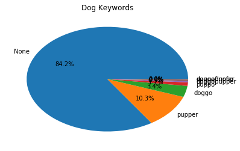

```python
#create a pie chart for the keywords of dogs

%matplotlib inline

plt.pie(df_clean['dog_keyword'].value_counts(), autopct='%1.1f%%', labels = ['None', 'pupper', 'doggo', 'puppo', 'doggopupper', 'floofer', 'doggopuppo', 'doggofloofer']);
plt.title('Dog Keywords');
```

We see from the pie chart that most dogs don't have keywords, and of the ones that do, most are "pupper" and "doggo", with less being "floofer" and "puppo", and even less having multiple keywords.

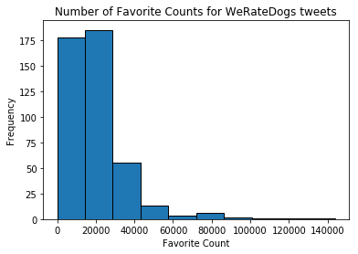

```python
#create a histogram for distribution of favorite counts

plt.hist(df_json['favorite_count'], bins=10, edgecolor='black');
plt.xlabel('Favorite Count')
plt.ylabel('Frequency')
plt.title('Number of Favorite Counts for WeRateDogs tweets')
plt.show();
```

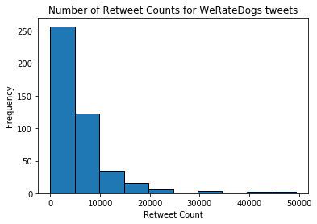

```python
#create a histogram for distribution of retweet counts

plt.hist(df_json['retweet_count'], bins=10, edgecolor='black');
plt.xlabel('Retweet Count')
plt.ylabel('Frequency')
plt.title('Number of Retweet Counts for WeRateDogs tweets')
plt.show();
```

This histogram is very similar to the distribution of the favorites one, with most tweets having between 1000-10000 retweets, and few going as high as 50k.

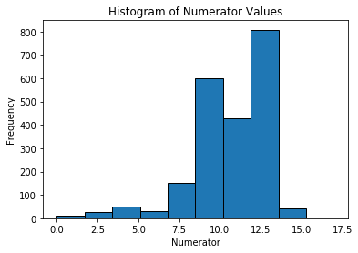

```python
# create a histogram for distribution of rating numerators

plt.hist(df_clean.query('rating_numerator < 20')['rating_numerator'], edgecolor='black')
plt.xlabel('Numerator')
plt.ylabel('Frequency')
plt.title('Histogram of Numerator Values')
plt.show();
```

From this histogram, we can see that most rating numerators fall within the 11-13 range.

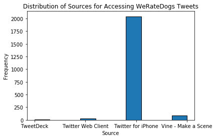

```python
plt.hist(df_clean['source'], edgecolor='black')
plt.xlabel('Source')
plt.ylabel('Frequency')
plt.title('Distribution of Sources for Accessing WeRateDogs Tweets')
plt.show();
```

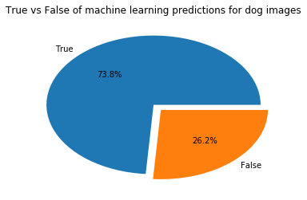

```python
plt.pie(images_clean['prediction_1_dog'].value_counts(), labels=['True', 'False'], autopct = '%1.1f%%', explode =(0, 0.1))
plt.title('True vs False of machine learning predictions for dog images');
```

```python
## save final merged dataframe to CSV

df_final.to_csv('df_final', index=False)
```